# Introduction to Python

Nathan Watkins

7/1/2020

[figure not shown]

# Contents

1. Overview
- Jupyter/Python Basics
- Libraries/Packages
- Compatibility
- Additional example
- Wrap-up

# 1. Overview

## What is Python

Python is a free and open-source general programming language that was created in 1990 by Guido van Rossum. It is natively object-oriented, though strict OOP is practiced mostly in software engineering. Python is popular in fields related to data science and analytics thanks to some of its useful libraries (e.g., Numpy, Pandas).

## Python facts

Python is...

- **interpreted**, so it does not need to be compiled into machine language
- **interactive**, allowing programs to be executed and debugged piece by piece
- **compatible** with many platforms and languages
- **easy** to read and maintain
- **high-level**, abstracted from computer processes
- **minimalist** in style, punctuation, and syntax
- **strict about indentation**, indifferent about brackets and semicolons
- **fast** (often if not always) - see the below figure showing log-likelihood computation times in a GARCH(1,1,) model for a dataset of length 10,000:

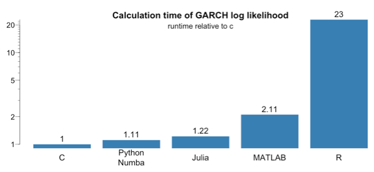

## Setup

You need three things to set up Python:

1. Download the Windows/Mac/Linux installer at python.org
- Set up the PATH variable, which is a named string that points the OS to programs and executables stored on your computer and called when you run a Python program
- Environment in which to start Python:
  - Command line
  - IDE (PyCharm, Spyder)
  - Interactive interpreter

## Anaconda

Anaconda is a popular distribution of Python (and R) that simplifies package deployment and updates.

### Anaconda Navigator

You can scroll through the contents of Anaconda by opening the Navigator:

[figure not shown]

### Anaconda Environments for Python

#### The Spyder IDE

Spyder looks a lot like RStudio and MATLAB.

[figure not shown]

#### Jupyter Notebooks

Jupyter Notebooks are what we are viewing right now. They are widely used in finance, tech, and data science because they simplify creating and sharing Python projects.

[figure not shown]